# Лабораторная работа №1

Установка и конфигурация операционной системы на виртуальную машину

Казначеева Кристина Никитична

НММ-02-24

# Информация

## Докладчик

- Казначеева Кристина Никитична
- Студент факультета физико-математических и естественных наук
- Российский университет дружбы народов
- 1132246773@pfur.ru

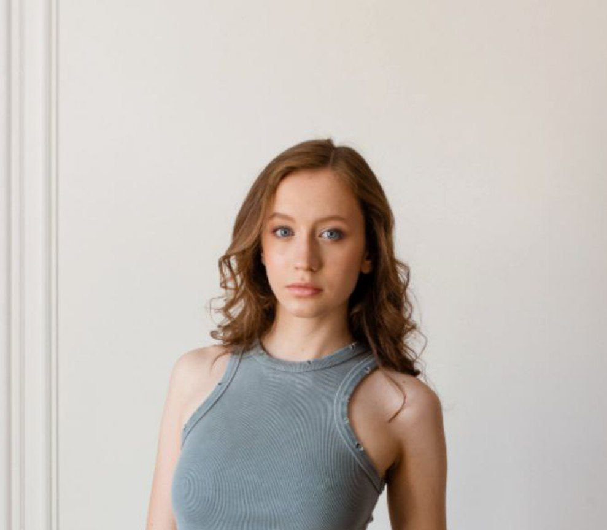

# Вводная часть

## Актуальность

Современная IT-индустрия требует глубокого знания Linux. Этот курс предоставляет фундаментальные навыки работы в Linux-окружении для разработки, администрирования, тестирования, исследований и создания технической документации (Markdown, TeX Live), используя VirtualBox для упрощения обучения и экспериментов. Это закладывает основу для дальнейшего изучения Linux и смежных технологий.

## Объект и предмет исследования

Установка операционной системы Linux на виртуальной машине VirtualBox с последующей установкой инструментов для работы с Markdown и TeX Live.

## Материалы и методы

Данная работа включает в себя следующие этапы: установка графического дистрибутива Linux в VirtualBox, настройка системы через командную строку (автообновление, SELinux, раскладка клавиатуры), установка Markdown и TeX Live с помощью менеджера пакетов (apt/dnf) и тестирование работоспособности установленного ПО с помощью тестовых документов.

# Выполнение работы

## Работа в VirtualBox

Запустим терминал, перейдя в каталог /var/tmp и создадим каталог с именем пользователя. Проведём настройку папки в VirtualBox и создадим виртуальную машину с необходимыми настройками. Выберем язык интерфейса.

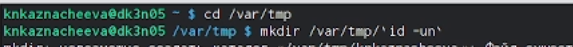

Создание каталога

[figure not shown]

## Запустим виртуальную машину

При установке необходимых настроек укажем имя виртуальной машины, тип операционной системы и т.д. Войдём в ОС под заданной при установке учётной записью. Нажмём комбина- цию Win+Enter для запуска терминала

[figure not shown]

[figure not shown]

## Обновление всех пакетов

Переключимся на роль супер-пользователя, а затем обновим все пакеты.

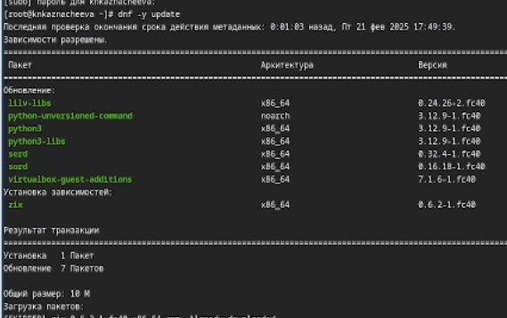

Обновим все пакеты

## Автоматическое обновление

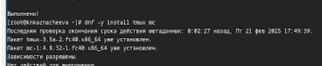

Программы для удобства работы в консоли

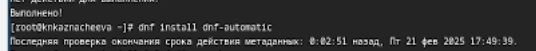

Программное обеспечение для автоматического обновления

## Отключение SELinux

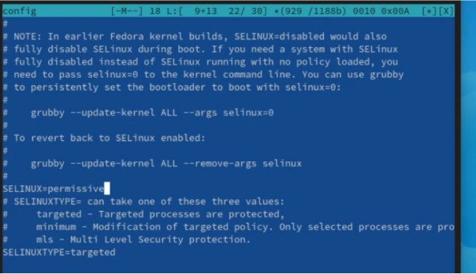

## Настройка раскладки клавиатуры

Создадим конфигурационный файл ~/.config/sway/config.d/95-system-keyboard- config.conf и отредактируем его.

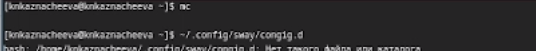

## Установка имени пользователя

Создадим пользователя, а позже зададим пароль для пользователя.

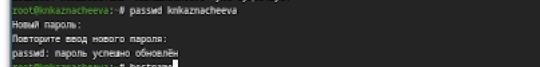

Пароль для пользователя

## Установка названия хоста

Установим имя хоста и проверим, что имя хоста установлено верно.

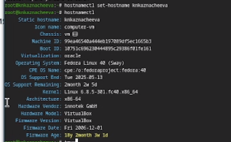

Установка имени хоста

## Установка программного обеспечения для создания документации и установка texlive

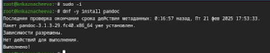

Установка средство pandoc

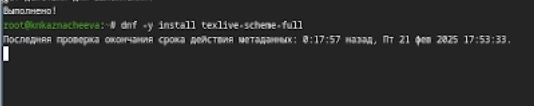

Установка texlive

## Домашнее задание

Получим информацию о версии ядра Linux (Linux version) и модели процессора (CPU0) с помощью greb.

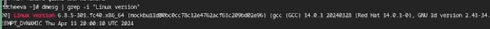

Версия ядра Linux

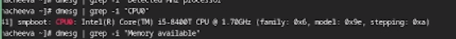

Модель процессора

## Домашнее задание

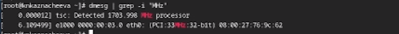

Частота процессора

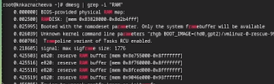

## Домашнее задание

С помощью grep получим информацию о типе файловой системы корневого раздела и последовательности монтирования файловых систем.

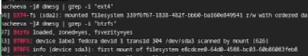

Тип файловой систем корневого раздела

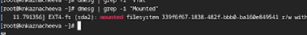

Последовательность монтирования файловых систем

# Результаты

## Выводы

Результатом работы стало создание полностью функциональной среды разработки на базе Linux в VirtualBox. Были успешно освоены навыки установки операционной системы, её базовой настройки, установки необходимого программного обеспечения (Markdown, TeX Live), работы в командной строке и управления пакетами.

## Спасибо за внимание

Спасибо за внимание!